# Limit of Detection scRNA Analysis

```r
library(SingleCellExperiment)
library(dplyr)
library(readxl)
library(scran)
library(scater)
library(Seurat)
library(magrittr)
library(BiocGenerics)
library(AnnotationHub)
library(EnsDb.Hsapiens.v86)
library(DESeq2)
library(edgeR)
library(Seurat)
library(forcats)
library(ggplot2)
library(reshape2)
library(ggrepel)

top_cumprop <- function(x, chosen) {
    out <- perCellQCMetrics(x, percent_top=chosen, flatten=FALSE)
    out$percent_top
}

# Apply same theme to all graphs
theme_set(theme_classic())
theme_update(text = element_text(size=12),
panel.grid.major = element_blank(),
panel.grid.minor = element_blank(),
strip.background = element_blank()
)

themes <-theme(text = element_text(),
  panel.grid.major = element_blank(),
  panel.grid.minor = element_blank(),
  strip.background = element_blank(),
  panel.background=element_rect(colour='black')
  )
```

```r
ggsave('avg_exp_1vs_100.png', avg.exp.plot)
```

Create SingleCellExperiment Object from UMI Matrix.

```r
# Load counts matrix
sce_mat <- read.csv('/hpc/scratch/hdd2/fs541623/scRNAseq/Run1_LimitOfDetection_160421/Primary_Data/ExpressionmatrixLOD_168602.csv')
tempo_seq <- read.csv('/hpc/scratch/hdd2/fs541623/scRNAseq/Bulk_Data_tempoSeq/tempo_seq_full_matrix.csv')
cell_metrics <- read.csv('/hpc/scratch/hdd2/fs541623/scRNAseq/Run1_LimitOfDetection_160421/Primary_Data/cell_metrics.csv')

# R2 reads
index_reads <- c('X1cell_S8_49',
    'X1cell_S8_50','X1cell_S8_51','X2cells_S7_61','X3cells_S6_74','X20cells_S3_14','X50cells_S2_2')

# Filter R2 reads
sce_df <- sce_mat[, !(colnames(sce_mat) %in% index_reads)] %>%
  dplyr::select(-c(gene.id, gene, strand, chrom, loc.5., loc.3.))
samples <- factor(str_extract(colnames(sce_df), '\\d+cell'))

# Single Cell Experiment object
sce_lod <- SingleCellExperiment(list(counts=as.matrix(sce_df)),
  rowData=DataFrame(chrom=sce_mat$chrom,
  strand=sce_mat$strand,
  symbol=sce_mat$gene,
  loc5=sce_mat$loc.5.,
  loc3=sce_mat$loc.3.,
  length=abs(sce_mat$loc.5. - sce_mat$loc.3.)),
  colData=DataFrame(sample=samples),
  metadata=list(study='LimitOfDetectionAssay',
  cells='Human RPTEC',
  description='To determine the limit of detection of UPX3transcriptomicKit'))

# Make sure 1:1 mapping of ensID : Gene Symbols
rownames(sce_lod) <- sce_mat$gene.id
rownames(sce_lod) <- uniquifyFeatureNames(rownames(sce_lod), rowData(sce_lod)$symbol)

# strand column otherwise causes error in downstream processing
mcols(sce_lod) <- as.data.frame(mcols(sce_lod)) %>% dplyr::select(-strand)
mcols(sce_lod) <- (mcols(sce_lod))
```

Dunn test to compare statistical difference in gene counts between groups

```r
## No significant differences ??
cell_metrics_df <- as.data.frame(cell_metrics)
sample_type <- str_split(cell_metrics_df$Cells, simplify = T, '_')[,1]
cell_metrics_df$sample_type <- sample_type

dunn_test <- capture.output(dunn.test::dunn.test(cell_metrics_df$detected.genes, cell_metrics_df$sample_type, method='bonferroni'))
write.csv(dunn_test, 'dunn_test_run1_samples.csv')
```

QC plots to assess sensitivity

```r
### get metrics
umis_per_cell <- Matrix::colSums(counts(sce_lod))
genes_per_cell <- Matrix::colSums(counts(sce_lod) > 0)
umis_per_gene_cell <- umis_per_cell/genes_per_cell
umis_per_gene <- Matrix::rowSums(counts(sce_lod))

## barplot umis per cell
root <- '/hpc/scratch/hdd2/fs541623/scRNAseq/Run1_LimitOfDetection_160421/Secondary_Analysis'
sce_lod$sample <- factor(sce_lod$sample, levels=c('1cell','2cell','3cell','5cell','10cell', '20cell', '50cell','100cell'))
png(paste0(root, '/Graphs/umis_per_per_cell.png'))
barplot(umis_per_cell, col=cc[sce_lod$sample], border=cc[sce_lod$sample], main='Transcripts (UMIs) per cell', xaxt='n')
legend('topleft', fill=cc, legend=levels(sce_lod$sample), cex=1, ncol=2)

## barplot genes per cell
png(paste0(root, '/Graphs/genes_per_per_cell.png'))
barplot(genes_per_cell, col=cc[sce_lod$sample], border=cc[sce_lod$sample], main='Genes per cell', xaxt='n')
legend('topleft', fill=cc, legend=levels(sce_lod$sample), cex=1, ncol=2)

## barploy umis per cell/genes per cell
png(paste0(root, '/Graphs/umis_genes_per_cell.png'))
barplot(umis_per_gene_cell, col=cc[sce_lod$sample], border=cc[sce_lod$sample], main='Transcripts (UMIs) / genes', xaxt='n')
legend('topleft', fill=cc, legend=levels(sce_lod$sample), cex=1, ncol=2)
```

Rough check of Highly variable genes (shouldnt really be normalizing over the different groups as a whole as they have very different sequencing depths). Still good to get a rough idea of what are the most variable genes across groups.

```r
## Normalization
s <- CreateSeuratObject(counts(sce_lod))
s <- SCTransform(s)
top_hvg <- HVFInfo(s) %>%
  mutate(., bc = rownames(.)) %>%
  arrange(desc(residual_variance)) %>%
  top_n(1000, residual_variance)  %>%
  rename(gene_name=bc) %>%
  left_join(., annotations, by='gene_name')
DefaultAssay(s) <- 'SCT'
top_100 <- top_hvg %>% top_n(50, residual_variance) %>% pull(gene_name)
s <- GetResidual(s, features=top_100, verbose=F)
s$sample <- sce_lod$sample
DoHeatmap(s, features=top_100, slot = "scale.data", group.by = 'sample') +
  scale_fill_gradient2(low = "#56B4E9", mid = "white", high = "#FF2800")
ggsave(paste0(root, '/Graphs/heatmap_hvg.png'))
write.csv(top_hvg, paste0(root, '/tables/HVG_log.csv'))
```

```r
# combine with temposeq negative control data
temp.df <- as.data.frame(counts(sce_tempo)) %>% rowMeans(.) %>% as.matrix(.)
rownames(temp.df) <- rowData(sce_tempo)$gene
temp.df <- as.data.frame(temp.df) %>% tibble::rownames_to_column(var='gene')
colnames(temp.df) <- c('gene', 'Bulk')


# combining temposeq and sc
sc.df <- as.data.frame(counts(sce_lod)) %>% mutate(gene=rowData(sce_lod)$symbol)
bulk.sc.merge <- as.matrix(merge(temp.df, sc.df, by='gene', all=T))[,2:26] # 22286 total genes
bulk.sc.merge <- apply(bulk.sc.merge, 2, as.numeric)
bulk.sc.merge[is.na(bulk.sc.merge)] <- 0
bulk.sc.sce <- SingleCellExperiment(list(counts=bulk.sc.merge),colData=DataFrame(sample=c(rep('bulk RNAseq', 1), str_extract(sce_lod$sample, '\\d+'))))

# order values for plotting
ordered <- as.numeric(colnames(bulk.sc.merge)) %>% order(.) # order for plotting
genes_per_rep <- Matrix::colSums(counts(bulk.sc.sce)> 0)


# barplot comparing genes in temposeq and genes in sensitivity tett
png('bulk_vs_sc_counts.png')
ordered <- as.numeric(str_extract(bulk.sc.sce$sample, '\\d+')) %>% order(.) # order for plotting
 # order for plotting
barplot(genes_per_rep[ordered], col=cc[factor(bulk.sc.sce$sample)[ordered]], main="Genes per  Replicate", xaxt='n')
legend("topleft", legend=levels(factor(bulk.sc.sce$sample)[ordered]), fill=cc, cex=1, ncol=3)
```

scRNAseq introduces significant variability between replicates. The variability decreases at larger cell numbers

```r
## TO DO SAVE PLOTS
count_df <- as.data.frame(counts(sce_lod)) %>% tibble::rownames_to_column(var='Gene')

# replicate plot for 1 cell
p1 <- ggplot(count_df) + geom_point(aes(x=count_df$X1cell_S8_85, y=count_df$X1cell_S8_86), size=0.6, alpha=0.6, colour='#E41A1C') + labs(x='\nReplicate 1', y='Replicate 2\n') + themes
p2 <- ggplot(count_df) + geom_point(aes(x=count_df$X1cell_S8_85, y=count_df$X1cell_S8_87), size=0.6, alpha=0.6, colour='#377EB8') + labs(x='\nReplicate 1', y='Replicate 3\n') + themes
p3 <- ggplot(count_df) + geom_point(aes(x=count_df$X1cell_S8_86, y=count_df$X1cell_S8_87), size=0.6, alpha=0.6, colour='#4DAF4A') + labs(x='\nReplicate 2', y='Replicate 3\n') + themes
rep_var1 <- cowplot::plot_grid(p1, p2, p3, ncol = 3)

# replicate plot for 100 cells
p100 <- ggplot(count_df) + geom_point(aes(x=count_df$X100cells_S1_1, y=count_df$X100cells_S1_2), size=0.6, alpha=0.6, colour='#E41A1C') + labs(x='\nReplicate 1', y='Replicate 2\n') + themes
p200 <- ggplot(count_df) + geom_point(aes(x=count_df$X100cells_S1_1, y=count_df$X100cells_S1_3), size=0.6, alpha=0.6, colour='#377EB8') + labs(x='\nReplicate 1', y='Replicate 3\n') + themes
p300 <- ggplot(count_df) + geom_point(aes(x=count_df$X100cells_S1_2, y=count_df$X100cells_S1_3), size=0.6, alpha=0.6, colour='#4DAF4A') + labs(x='\nReplicate 2', y='Replicate 3\n') + themes
rep_var100 <- cowplot::plot_grid(p100, p200, p300, ncol = 3)
comp_1_100 <- cowplot::plot_grid(rep_var, rep_var100, ncol=1, nrow=2)

ggsave(comp_1_100, filename='replicate_noise.png')
```

Proportion of Mitochondrial Genes is a good metric for low quality libraries e.g. mitochondrial gene expression indicative of apoptosis. Additionally, it is harder for mtRNA to be lost from a cell than mRNA as mtRNA is contained.

[figure not shown]

Assess if rRNA depletion was successful by the % of rRNA reads Compare rRNA and mtRNA counts

```r
## Do Graph of mitochrondial Genes Detected and Ribosomal Genes Detected
get_ribo_gene_count <- function(sample_number){
  tmp <- rownames(split.sample[[sample_number]]@assays$RNA)[rowSums(split.sample[[sample_number]][['RNA']]@counts > 0) >0]
  ribo.genes <- sum(grepl('^RP', tmp))
}
get_mito_gene_counts <- function(sample_number){
  tmp <- rownames(split.sample[[sample_number]]@assays$RNA)[rowSums(split.sample[[sample_number]][['RNA']]@counts > 0) >0]
  mito.genes <- sum(grepl('^MT-', tmp))
}

# Ribosomal RNA gene count
ribo_count <- lapply(c('1','2','3','5','10', '20','50','100'), get_ribo_gene_count)
names(ribo_count) <- c('1','2','3','5','10', '20','50','100')
# Mito gene count
mito_count <- lapply(c('1','2','3','5','10', '20','50','100'), get_mito_gene_counts)
names(mito_count) <- c('1','2','3','5','10', '20','50','100')
# Table of combined mito & rio reads
mito.ribo.genes <- rbind(mito_count, ribo_count)
knitr::kable(mito.ribo.genes)
```

For each library assess the % attributed to the most abundant Genes detected across samples; a measure of the ‘complexity’ of libraries. Are just a few genes expressed at high numbers or do the UMI counts include high expression across a variety of genes.

```r
ggplot(top500, aes(factor(sample), mean,fill=I(mean_prop))) +
  geom_bar(stat=\identity\, position=position_dodge()) +
  geom_errorbar(aes(ymin=mean-(sds/sqrt(3)), ymax=mean+(sds/sqrt(3))), width=.2,
                 position=position_dodge(.9)) +
  scale_fill_gradient(low='#9ec2ff', high='#03108c') +
  labs(x='\nCells per Sample Group', y=\Average Genes Detected\n\, fill='Cumulative % of Top500 Abundant Genes') +
  theme(
  legend.position = 'bottom',
  panel.grid.major = element_blank(),
  panel.grid.minor = element_blank(),
  strip.background = element_blank(),
  legend.position='bottom',
  panel.background=element_rect(colour='black')
  ) +
  guides(col=guide_legend(col='Cumulative % of Top500 Abundant Genes'))
```

[output not shown]

Ignore: Assuming there are 30,000 Genes in Genome, what percentage of whole Genome was detected

```r
ggsave(cell1.vs.100, filename='QC/transcriptome_cov.png')
```

Assess sensitivity of sequencing looking at number of detected Genes with different amounts of starting material

```r
## TO DO
percentage.genome <- seurat.obj@meta.data$nCount_RNA/30000
percent.genome.cov <- data.frame(percentage.genome, sample=as.integer(seurat.obj@meta.data$sample)) %>% group_by(sample) %>% summarise(mean_percent=mean(percentage.genome), sds=sd(percentage.genome)) %>%
  arrange(sample) %>%
  ggplot(., aes(factor(sample), mean_percent)) +
  geom_bar(stat='identity', fill='#fada5e') +
  labs(x='\nCells per Sample', y='% Genome Coverage\n') +
  geom_errorbar(aes(ymin=mean_percent-sds/sqrt(3), ymax=mean_percent+sds/sqrt(3)), width=.2, position=position_dodge(.9))
ggsave(percent.genome.cov, filename='QC/pecent_genome.png')
# Detected Genes
detectedgenes <- colSums(counts(sce_lod) > 0)
names(detectedgenes) <- stringr::str_extract(names(detectedgenes), pattern='[0-9]+')

# Gene counts
df_genes <- data.frame(total_genes=detectedgenes, sample=as.integer(names(detectedgenes))) %>%
  group_by(sample) %>%
  summarise(mean=mean(total_genes), sds=sd(total_genes)) %>%
  arrange(as.integer(sample))

# gg of gene counts
detectedGenes_gg <- ggplot(df_genes, aes(factor(sample), mean)) +
  geom_bar(stat=\identity\, fill=\#b5e2ff\, colour='black',position=position_dodge()) +
  geom_errorbar(aes(ymin=mean-sds/sqrt(3), ymax=mean+sds/sqrt(3)), width=.2,
                 position=position_dodge(.9)) +
  labs(x='\nCells per Sample Group', y='Average Genes Detected\n')
ggsave(detectedGenes_gg, filename='QC/detectedgenes.png')
```

How does sequencing depth change as amount of starting material changes?

```r
# reads
df_reads <- data.frame(reads =seurat.obj@meta.data$nCount_RNA, sample=as.integer(seurat.obj@meta.data$sample)) %>%
  group_by(sample) %>%
  summarise(mean=mean(reads), sds=sd(reads)) %>%
  arrange(as.integer(sample))

dim(df_reads)
# gg of reads
reads_gg <- ggplot(df_reads, aes(factor(sample), mean,  fill='coral')) +
  geom_bar(stat=\identity\, color=\black\, position=position_dodge()) +
  geom_errorbar(aes(ymin=mean-sds/sqrt(3), ymax=mean+sds/sqrt(3)), width=.2,
                 position=position_dodge(.9)) +
  labs(x='\nNumber of Cells', y='Mean UMI counts\n') + NoLegend()

## Gene vs Reads Scatter
genes.reads.scatter <- FeatureScatter(seurat.obj, feature2 = 'nFeature_RNA', feature1 = 'nCount_RNA', pt.size = 2, plot.cor=F) +
  scale_x_continuous('\nTotal UMI Counts', breaks=c(10000, 50000, 100000, 140000), labels=scales::comma) +
  labs(y='Detected Genes\n', colour='Cells per Sample') +
  theme(text = element_text(),
  panel.grid.major = element_blank(),
  panel.grid.minor = element_blank(),
  strip.background = element_blank(),
  panel.background=element_rect(colour='black')
  )

ggsave(reads_gg, filename='QC/reads.png')
ggsave(genes.reads.scatter, filename='QC/reads_vs_genes.png')
```

Heatmap of genes with highest expression.

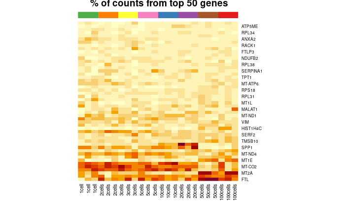

Normalize across replicates (not samples) using seurat, regressing out sequencing depth, mitochondrial %, and ribo % Find top highly variable Genes in each sample

```r
split.sample <- lapply(split.sample, SCTransform, min_cells=1, method='glmGamPoi',
                       vars.to.regress=c('mito.percent', 'nCount_RNA'),  return.only.var.genes = F)
```

[output not shown]

```r
# Plot Aggregate Expression for 1 cell and 100 cell
# Get Expression for 1 cell
cell.1.agg <- subset(seurat.obj, idents='1')
cell.1.df.agg <- as.data.frame(AggregateExpression(cell.1.agg, verbose=F, slot='counts')$RNA)
cell.1.df.agg$gene <- rownames(cell.1.df.agg)
colnames(cell.1.df.agg) <- c('cell1', 'Gene')

# Get Expression for 100 cell
cell.100.agg <- subset(seurat.obj, idents=c('100','1'))
cell.100.df.agg <- as.data.frame(AggregateExpression(cell.100.agg, verbose=F, slot='counts')$RNA)
cell.100.df.agg$gene <- rownames(cell.100.df.agg)
colnames(cell.100.df.agg) <- c('cell100', 'Gene')
```

Compare sequencing depth in 1 vs 100 cells, via average expression of Genes

[figure not shown]

```r
# replicate plot # 100 cells
rep_1cell_pl <- as.data.frame(cell.100@assays[['RNA']]@counts) %>% ggplot(., aes(.[[2]], .[[1]])) + geom_point() + scale_x_continuous(scales::pseudo_log_trans()) + scale_y_continuous(scales::pseudo_log_trans()) + themes

# replicate plot # 1 cell
rep_100cell_pl <- as.data.frame(cell.100@assays[['RNA']]@counts) %>% ggplot(., aes(.[[5]], .[[6]])) + geom_point() + scale_x_continuous(scales::pseudo_log_trans()) + scale_y_continuous(scales::pseudo_log_trans()) + themes

# combined plot
rep_plot <- cowplot::plot_grid(rep_100cell_pl, rep_1cell_pl)
ggsave('QC/rep_plot_1vs_100.png', rep_plot)
```

Some basic pathway analysis; Gene list of genes with count >1 for each sample passed in, to get rough estimate of pathways across samples.Difficult to do comparisons as difficult to integrate across samples with only 3 replicates, so there is large batch effect between groups

```r
cell1 <- read.csv('/hpc/scratch/hdd2/fs541623/scRNAseq/LOD_Analysis/reactome/cell_1.csv')
cell5 <- read.csv('/hpc/scratch/hdd2/fs541623/scRNAseq/LOD_Analysis/reactome/cell_5.csv')
cell100 <- read.csv('/hpc/scratch/hdd2/fs541623/scRNAseq/LOD_Analysis/reactome/cell_100.csv')

## Common pathways
##df.reactome <- data.frame(percentage1=cell1$Percentage.of.Genes.found.in.pathway,
##                          percentage5=cell5$percentage,
##                          percentage100=cell100$Percentage,
##                          pathway=cell1$Pathway.name) %>%
##                          dplyr::filter(., pathway == common.pathways) %>%
##                          tidyr::pivot_longer(., -pathway, names_to='sample',                                        ##     values_to='percentage')

## Data frames for all 'interesting'reactom.df.1 <- data.frame(percentage.of.pathway = cell1$Percentage.of.Genes.found.in.pathway

reactom.df.1 <- data.frame(percentage=cell1$Percentage.of.Genes.found.in.pathway,
                           sample=cell1$Sample.type,
                           pathway=cell1$Pathway.name)
reactom.df.5 <- data.frame(percentage=cell5$percentage,
                           sample=cell5$sample,
                           pathway=cell5$Pathway.name)
reactom.df.100 <- data.frame(percentage=cell100$Percentage,
                            sample=cell100$sample,
                            pathway=cell100$Pathway.name)

# Format for plotting
allrows<- Reduce(rbind, list(reactom.df.1, reactom.df.5, reactom.df.100)) %>%
                            dplyr::filter(., pathway %in% selected_pathways)
df.reactom <- allrows %>% tidyr::pivot_wider(., names_from=sample,
                            values_from=percentage)%>% melt(.)

View(df.reactom)
gg.reactom <- df.reactom %>%
  ggplot(., aes(x=pathway, y=value, fill=variable)) +
  geom_bar(stat='identity', position=position_dodge()) +
  theme(axis.text.x = element_text(angle=45, hjust=1)) +
  scale_x_discrete(labels=c('SRP-co-translation',
                            'selenocysteine synthesis',
                            'Amino acid defeciency',
                            'Electron Transport',
                            'SLITS & ROBOS Regulation',
                            'Silencing of ceruloplasmin Expression',
                            'Endosomal/Vacuolar',
                            'Starvation',
                            'mRNA destabilisation by AUF')) +
  labs(fill='Sample', y='% Genes in Pathway')

ggsave(gg.reactom, filename='QC/reactom_pathways.png')


## Interesting seleceted pathways, including all common
selected_pathways <- c('Activation of APC/C and APC/C:Cdc20 mediated degradation of mitotic
                        proteins',
                       'Cellular response to starvation',
                       'L13a-mediated translational silencing of Ceruloplasmin expression',
                       'AUF1 (hnRNP D0) binds and destabilizes mRNA',
                       'Regulation of expression of SLITs and ROBOs',
                       'Response of EIF2AK4 (GCN2) to amino acid deficiency',
                       'SRP-dependent cotranslational protein targeting to membrane',
                       'Endosomal/Vacuolar pathway',
                       'Selenocysteine synthesis',
                       'Respiratory electron transport')

# merge all pathways together
df.allpathways <-merge(merge(df.all.pathways.100, df.all.pathways.5, by='pathway', all=T),
                      df.all.pathways.1, by='pathway', all=T) %>%
                      dplyr::filter(., pathway %in% selected_pathways) %>%
                      replace(is.na(.), 0) %>%
                      tidyr::pivot_wider()

common.pathways <- Reduce(intersect, list(cell1$Pathway.name, cell5$Pathway.name, cell100$Pathway.name))
```

```r
read.reactome <- function(sample_group, df){
  dir <- '/hpc/scratch/hdd2/fs541623/scRNAseq/LOD_Analysis/reactome/'
  filename <- paste0(dir, 'cell_',sample_group,'_reactome.csv')
  pathway.number <- nrow(read.csv(filename))
}

pathways.csv <- lapply(c(1,2,3,5,10,20,100), read.reactome) %>% unlist()
names(pathways.csv) <- as.integer(c(1,2,3,5,10,20,100))

df.pathways.num <- data.frame(pathways=pathways.csv, sample=as.integer(c(1,2,3,5,10,20,100))) %>%
                arrange(as.integer(sample))

gg.pathways <-  ggplot(df.pathways.num, aes(factor(sample), pathways)) +
                geom_bar(stat='identity', fill='#7851a9') +
                labs(x='\n Cells per Sample', y='Pathways Detected\n')

ggsave(gg.pathways, filename='QC/pathway_number.png')
```

```r
## Split by normalization
split_df <- function(sample_group){
  tmp <- split.sample[[sample_group]]@assays$SCT@data
  filename <- paste0('pathway_analysis/', sample_group, '_normalized.csv')
  write.csv(tmp, file=filename)
}


exp_mat_split <- lapply(c('1','2','3','5','10', '20','50','100'), split_df)

## Save aggregate
write.csv(counts(agg_sce), file='pathway_analysis/aggregate_count.csv')

## Save replicate normalized, full exp matrix
seurat_comb <- Reduce(merge, split.sample)
write.csv(seurat_comb@assays$SCT@data, file='pathway_analysis/normalized_counts.csv')
```

```r
## Expression matrix split by sample
save_csv_raw <- function(sample_group){
  tmp <- split.sample[[sample_group]]@assays$RNA@data
  filename <- paste0('pathway_analysis/', sample_group, '_rawcounts.csv')
  write.csv(tmp, file=filename)
}

exp_mat_split <- lapply(c('1','2','3','5','10', '20','50','100'), save_csv_raw)

## Full expression matrix
write.csv(counts(sce_lod), file='pathway_analysis/full_raw_counts.csv')

## Full normalized expression matrix
seurat.obj_full_transform <- SCTransform(seurat.obj)
write.csv(seurat.obj_full_transform@assays$SCT@data, file='pathway_analysis/full_normalized_counts_.csv')
```

combine tempo and sc to model dropout rate in sc data. Logistic regression is a common method to model these dropout. Here tempo-seq was used as the ground truth. Firstly I merged tempo and sc data on common gene names. For genes expressed in tempo-seq but not expressed in sc-data a 0 value was imputed.

```r
tempo_meta <- read.csv('/hpc/scratch/hdd2/fs541623/scRNAseq/Bulk_Data_tempoSeq/temposeq_ensembl_ids.csv')
tempo_seq <- read.csv('/hpc/scratch/hdd2/fs541623/scRNAseq/Bulk_Data_tempoSeq/tempo_seq_full_matrix.csv')
sce_mat <- sce_mat[, !(colnames(sce_mat) %in% index_reads)]

# merge tempo metadata with temposeq matrix to get ensembl id
tempo_genes <- str_extract(tempo_seq$X, '.*?(?=_)')
temposeq_nacl <- tempo_seq[,is.na(str_extract(colnames(tempo_seq), 'NaCl')) == FALSE] %>%
                 mutate(Probe.Name=tempo_seq$X)
merged_tempo <- merge(temposeq_nacl, tempo_meta, by='Probe.Name', all=T)

# filter out genes not expressed
sce_tempo <- SingleCellExperiment(list(counts=as.matrix(merged_tempo[,2:10])),
                rowData=DataFrame(gene=merged_tempo$Gene.Symbol,
                                  ensembl=merged_tempo$ENSEMBL.Gene.ID))
rownames(sce_tempo) <- merged_tempo$gene

# filter out tempo genes with counts > 0
sce_tempo <- sce_tempo[rowSums(counts(sce_tempo) > 0) > 0,]
filtered_df <- as.data.frame(counts(sce_tempo)) %>%
               mutate(., gene=rowData(sce_tempo)$gene,
                         ensembl=rowData(sce_tempo)$ensembl)

# merge tempo and sc on genes
merged_sc_tempo <- merge(filtered_df, sce_mat, by='gene', all =T)
merged_sc_tempo[is.na(merged_sc_tempo)] <- 0
merged_sc_tempo <- merged_sc_tempo %>% dplyr::select(contains('cell'), gene, ensembl)

# quick check
View(merged_sc_tempo)
nrow(merged_sc_tempo)# 22286 FULL GENE LIST
length(tempo_genes) # 22547
sce_mat <- sce_mat[rowSums(sce_mat > 0) > 0,]
nrow(sce_mat) # 12889
```

logistic regression showing rate of failure for a given gene expression using tempo-seq as ground truth

```r
# merge temposeq data and single cell
sce_tempo_sc <- SingleCellExperiment(list(counts=merged_sc_tempo[,1:(ncol(merged_sc_tempo)-2)]),
                                     rowData=DataFrame((ensembl=merged_sc_tempo$ensembl),
                                                        gene=merged_sc_tempo$gene),
                                     colData=DataFrame(sample=factor(colname_split)))
mu_obs <- rowMeans(log10(counts(sce_tempo_sc)+1))



# Number of dropouts
drop_outs <- counts(sce_tempo_sc) == 0
dim(drop_outs)[2]

library(RColorBrewer)
cc <- c(brewer.pal(9, "Set1"), brewer.pal(8, "Set2"),brewer.pal(9,"Set3"))
cc[factor(sce_tempo_sc$sample)]
cc
```

[output not shown]

```r
nrow(filtered_df) # 19456 genes in temposeq data
nrow(sce_lod) # 12889 genes in sc
sc_specific_genes <- sce_lod[!(rownames(sce_lod) %in% filtered_df$gene),] # 2833 genes detected by sc not detected by tempo
rownames(sc_specific_genes)
```